# Data 622 Homework 4: Mental Health Data Modeling

## Additional Data (Processing) Manipulation Steps

So, first off, I need to convert Credit_History to factors so that the mice model that I’m going to use can detect that column as a categorical variable.

Combining ApplicantIncome and CoapplicantIncome into a new variable TotalIncome, and dropping the respective input columns. Loan_ID doesn’t help with the prediction obviously. So dropping it as well.

```r
loan_knn_pre_imp <- loan_knn
loan_knn_pre_imp$Credit_History <- as.factor(loan_knn_pre_imp$Credit_History)



loan_knn_pre_imp <- loan_knn_pre_imp %>% mutate(TotalIncome = ApplicantIncome + CoapplicantIncome)
loan_knn_pre_imp <- loan_knn_pre_imp %>% select(-c('Loan_ID','ApplicantIncome','CoapplicantIncome'))

# loan_knn_pre_imp[loan_knn_pre_imp$Dependents = "3+"] <- "3"

# recode dependents 3+ to 3
loan_knn_pre_imp$Dependents <- revalue(loan_knn_pre_imp$Dependents, c("3+"="3"))


str(loan_knn_pre_imp)
```

```
## 'data.frame':    614 obs. of  11 variables:
##  $ Gender          : Factor w/ 2 levels "Female","Male": 2 2 2 2 2 2 2 2 2 2 ...
##  $ Married         : Factor w/ 2 levels "No","Yes": 1 2 2 2 1 2 2 2 2 2 ...
##  $ Dependents      : Factor w/ 4 levels "0","1","2","3": 1 2 1 1 1 3 1 4 3 2 ...
##  $ Education       : Factor w/ 2 levels "Graduate","Not Graduate": 1 1 1 2 1 1 2 1 1 1 ...
##  $ Self_Employed   : Factor w/ 2 levels "No","Yes": 1 1 2 1 1 2 1 1 1 1 ...
##  $ LoanAmount      : int  NA 128 66 120 141 267 95 158 168 349 ...
##  $ Loan_Amount_Term: int  360 360 360 360 360 360 360 360 360 360 ...
##  $ Credit_History  : Factor w/ 2 levels "0","1": 2 2 2 2 2 2 2 1 2 2 ...
##  $ Property_Area   : Factor w/ 3 levels "Rural","Semiurban",..: 3 1 3 3 3 3 3 2 3 2 ...
##  $ Loan_Status     : num  1 0 1 1 1 1 1 0 1 0 ...
##  $ TotalIncome     : num  5849 6091 3000 4941 6000 ...
```

I’ve set up a predictorMatrix where I can instruct mice to use which method for which column for imputation.

Set seed = 501. Retrieved the results.

```r
# loan_knn_imp1 <- mice (loan_knn_pre_imp, method = c("",
#                                                     "logreg",
#                                                     "logreg",
#                                                     "polyreg",
#                                                     "",
#                                                     "logreg",
#                                                     "",
#                                                     "",
#                                                     "cart",
#                                                     "polr",
#                                                     "logreg",
#                                                     "",
#                                                     ""
#                                                    ), seed=501, nnet.MaxNWts = 30100
# )
#
# loan_knn_imp1 <- mice (loan_knn_pre_imp, seed=501, nnet.MaxNWts = 30100)
#
# loan_knn_imp2 <- mice (loan_knn_pre_imp, method = "rf", seed=501, nnet.MaxNWts = 30100)


# loan_knn_imp2 <- parlmice(data = loan_knn_pre_imp, method = c(  "",
#                                                                 "logreg",
#                                                                 "logreg",
#                                                                 "polyreg",
#                                                                 "",
#                                                                 "",
#                                                                 "",
#                                                                 "",
#                                                                 "cart",
#                                                                 "polr",
#                                                                 "logreg",
#                                                                 "",
#                                                                 ""
#                                                               ), cluster.seed = 501, nnet.MaxNWts = 30100, n.core = 2, n.imp.core = 150)



init <- mice(loan_knn_pre_imp, maxit=0)
meth <- init$method
predM <- init$predictorMatrix
# meth[c('Loan_Amount_Term')] <- 'polr'
# meth[c('LoanAmount')] <- 'cart'
meth[c('LoanAmount','Loan_Amount_Term')] <- 'norm'
meth[c('Credit_History','Self_Employed','Gender','Married')] <- 'logreg'
meth[c('Dependents')] <- 'polyreg'
meth[c('Loan_Status','TotalIncome','Property_Area','Education')] = ''
loan_knn_imp1 <- mice(loan_knn_pre_imp, method=meth, predictorMatrix=predM, seed=501)
```

After some manual examinations of the different imputed results, I’ve decided to go with imputed column #3.

```r
# Manual examination
#Credit_History
loan_knn[96:118,]
```

```
##      Loan_ID Gender Married Dependents    Education Self_Employed
## 96  LP001326   Male      No          0     Graduate          <NA>
## 97  LP001327 Female     Yes          0     Graduate            No
## 98  LP001333   Male     Yes          0     Graduate            No
## 99  LP001334   Male     Yes          0 Not Graduate            No
## 100 LP001343   Male     Yes          0     Graduate            No
## 101 LP001345   Male     Yes          2 Not Graduate            No
## 102 LP001349   Male      No          0     Graduate            No
##     ApplicantIncome CoapplicantIncome LoanAmount Loan_Amount_Term
## 96             6782                 0         NA              360
## 97             2484              2302        137              360
## 98             1977               997         50              360
## 99             4188                 0        115              180
## 100            1759              3541        131              360
## 101            4288              3263        133              180
## 102            4843              3806        151              360
##     Credit_History Property_Area Loan_Status
## 96              NA         Urban           0
## 97               1     Semiurban           1
## 98               1     Semiurban           1
## 99               1     Semiurban           1
## 100              1     Semiurban           1
## 101              1         Urban           1
## 102              1     Semiurban           1
##  [ reached 'max' / getOption("max.print") -- omitted 16 rows ]
```

```r
loan_knn_imp1$imp$Credit_History
```

```
##     1 2 3 4 5
## 17  1 1 1 1 1
## 25  0 0 1 0 0
## 31  1 1 0 0 0
## 43  1 1 1 1 1
## 80  1 1 1 1 1
## 84  0 1 0 0 1
## 87  1 1 1 1 1
## 96  0 0 0 1 1
## 118 1 1 1 1 1
## 126 1 1 1 1 1
## 130 1 0 1 0 1
## 131 1 1 1 1 1
## 157 1 1 1 1 1
## 182 1 1 0 1 1
## 188 1 1 1 1 1
## 199 1 0 1 1 1
## 220 1 1 1 1 1
## 237 1 1 1 1 0
## 238 1 1 1 1 1
## 260 0 0 0 0 0
##  [ reached 'max' / getOption("max.print") -- omitted 30 rows ]
```

```r
#Married
loan_knn[430:436,]
```

```
##      Loan_ID Gender Married Dependents    Education Self_Employed
## 430 LP002370   Male      No          0 Not Graduate            No
## 431 LP002377 Female      No          1     Graduate           Yes
## 432 LP002379   Male      No          0     Graduate            No
## 433 LP002386   Male      No          0     Graduate          <NA>
## 434 LP002387   Male     Yes          0     Graduate            No
## 435 LP002390   Male      No          0     Graduate            No
## 436 LP002393 Female    <NA>       <NA>     Graduate            No
##     ApplicantIncome CoapplicantIncome LoanAmount Loan_Amount_Term
## 430            2717                 0         60              180
## 431            8624                 0        150              360
## 432            6500                 0        105              360
## 433           12876                 0        405              360
## 434            2425              2340        143              360
## 435            3750                 0        100              360
## 436           10047                 0         NA              240
##     Credit_History Property_Area Loan_Status
## 430              1         Urban           1
## 431              1     Semiurban           1
## 432              0         Rural           0
## 433              1     Semiurban           1
## 434              1     Semiurban           1
## 435              1         Urban           1
## 436              1     Semiurban           1
```

```r
loan_knn_imp1$imp$Married
```

```
##       1   2   3   4   5
## 105 Yes Yes Yes  No Yes
## 229  No Yes Yes Yes  No
## 436  No Yes  No  No Yes
```

```r
#Dependents
loan_knn[227:229,]
```

```
##      Loan_ID Gender Married Dependents    Education Self_Employed
## 227 LP001754   Male     Yes       <NA> Not Graduate           Yes
## 228 LP001758   Male     Yes          2     Graduate            No
## 229 LP001760   Male    <NA>       <NA>     Graduate            No
##     ApplicantIncome CoapplicantIncome LoanAmount Loan_Amount_Term
## 227            4735                 0        138              360
## 228            6250              1695        210              360
## 229            4758                 0        158              480
##     Credit_History Property_Area Loan_Status
## 227              1         Urban           0
## 228              1     Semiurban           1
## 229              1     Semiurban           1
```

```r
loan_knn_imp1$imp$Dependents
```

```
##     1 2 3 4 5
## 103 3 0 1 2 0
## 105 0 0 2 0 3
## 121 2 2 2 0 2
## 227 2 3 3 2 2
## 229 0 0 0 1 0
## 294 1 1 0 0 0
## 302 2 1 0 0 0
## 333 0 2 3 0 0
## 336 1 1 2 0 2
## 347 2 0 3 3 1
## 356 0 0 0 0 1
## 436 0 1 0 0 1
## 518 3 1 1 3 2
## 572 2 1 0 0 0
## 598 0 0 0 0 0
```

```r
loan_knn2 <- complete(loan_knn_imp1, 3) # 2nd argument if not provided is defaulted to 1
```

## **Modeling with KNN**

First off, set seed = 688.

Create training/test partitions by calling createDataPartition. p is set to .8 to mean 80/20 split for train/test set.

Checking the structure of the train set (*knn_train*)

```r
set.seed(688)
# recoding Loan_Status back to categorical variable
loan_knn2$Loan_Status <- as.factor(loan_knn2$Loan_Status)
str(loan_knn2)
```

```
## 'data.frame':    614 obs. of  11 variables:
##  $ Gender          : Factor w/ 2 levels "Female","Male": 2 2 2 2 2 2 2 2 2 2 ...
##  $ Married         : Factor w/ 2 levels "No","Yes": 1 2 2 2 1 2 2 2 2 2 ...
##  $ Dependents      : Factor w/ 4 levels "0","1","2","3": 1 2 1 1 1 3 1 4 3 2 ...
##  $ Education       : Factor w/ 2 levels "Graduate","Not Graduate": 1 1 1 2 1 1 2 1 1 1 ...
##  $ Self_Employed   : Factor w/ 2 levels "No","Yes": 1 1 2 1 1 2 1 1 1 1 ...
##  $ LoanAmount      : num  114 128 66 120 141 ...
##  $ Loan_Amount_Term: num  360 360 360 360 360 360 360 360 360 360 ...
##  $ Credit_History  : Factor w/ 2 levels "0","1": 2 2 2 2 2 2 2 1 2 2 ...
##  $ Property_Area   : Factor w/ 3 levels "Rural","Semiurban",..: 3 1 3 3 3 3 3 2 3 2 ...
##  $ Loan_Status     : Factor w/ 2 levels "0","1": 2 1 2 2 2 2 2 1 2 1 ...
##  $ TotalIncome     : num  5849 6091 3000 4941 6000 ...
```

```r
# Data Partitioning
trainIndex <- createDataPartition(loan_knn2$Loan_Status, p = .8, list = FALSE, times = 1)
knn_train <- loan_knn2[trainIndex,]
knn_test  <- loan_knn2[-trainIndex,]



str(knn_train)
```

```
## 'data.frame':    492 obs. of  11 variables:
##  $ Gender          : Factor w/ 2 levels "Female","Male": 2 2 2 2 2 2 2 2 2 2 ...
##  $ Married         : Factor w/ 2 levels "No","Yes": 1 2 2 2 2 2 2 2 2 2 ...
##  $ Dependents      : Factor w/ 4 levels "0","1","2","3": 1 2 1 1 1 4 3 3 3 3 ...
##  $ Education       : Factor w/ 2 levels "Graduate","Not Graduate": 1 1 1 2 2 1 1 1 1 1 ...
##  $ Self_Employed   : Factor w/ 2 levels "No","Yes": 1 1 2 1 1 1 1 1 1 1 ...
##  $ LoanAmount      : num  114 128 66 120 95 ...
##  $ Loan_Amount_Term: num  360 360 360 360 360 360 360 360 360 360 ...
##  $ Credit_History  : Factor w/ 2 levels "0","1": 2 2 2 2 2 1 2 2 2 2 ...
##  $ Property_Area   : Factor w/ 3 levels "Rural","Semiurban",..: 3 1 3 3 3 2 3 3 3 3 ...
##  $ Loan_Status     : Factor w/ 2 levels "0","1": 2 1 2 2 2 1 2 2 2 2 ...
##  $ TotalIncome     : num  5849 6091 3000 4941 3849 ...
```

Checking the structure of the test set (*knn_test*)

```r
str(knn_test)
```

```
## 'data.frame':    122 obs. of  11 variables:
##  $ Gender          : Factor w/ 2 levels "Female","Male": 2 2 2 2 2 2 2 2 1 2 ...
##  $ Married         : Factor w/ 2 levels "No","Yes": 1 2 2 2 2 1 1 2 2 2 ...
##  $ Dependents      : Factor w/ 4 levels "0","1","2","3": 1 3 2 3 3 2 4 3 2 1 ...
##  $ Education       : Factor w/ 2 levels "Graduate","Not Graduate": 1 1 1 2 2 1 1 1 1 1 ...
##  $ Self_Employed   : Factor w/ 2 levels "No","Yes": 1 2 1 1 1 2 1 1 2 1 ...
##  $ LoanAmount      : num  141 267 349 112 110 106 320 134 286 96 ...
##  $ Loan_Amount_Term: num  360 360 360 360 360 360 360 360 360 360 ...
##  $ Credit_History  : Factor w/ 2 levels "0","1": 2 2 2 1 2 2 2 2 1 2 ...
##  $ Property_Area   : Factor w/ 3 levels "Rural","Semiurban",..: 3 3 2 1 3 1 1 3 3 2 ...
##  $ Loan_Status     : Factor w/ 2 levels "0","1": 2 2 1 1 2 1 1 1 1 2 ...
##  $ TotalIncome     : num  6000 9613 23809 5282 5266 ...
```

### Cross Validation

```r
trControl <- trainControl(method  = "repeatedcv",
                          repeats  = 11)
knn.fit <- train(Loan_Status ~ .,
             method     = "knn",
             tuneGrid   = expand.grid(k = 1:10),
             trControl  = trControl,
             preProcess = c("center","scale"),
             data       = knn_train
             )
```

Since our target variable is a binary factor of 2, by default, we use Accuracy as the determining performance metric. The optimal K is thus determined by Accuracy. **K = 9 was finally selected.** # of neighbors is 9.

```r
# getOption("max.print")
knn.fit
```

```
## k-Nearest Neighbors
##
## 492 samples
##  10 predictor
##   2 classes: '0', '1'
##
## Pre-processing: centered (13), scaled (13)
## Resampling: Cross-Validated (10 fold, repeated 11 times)
## Summary of sample sizes: 442, 444, 443, 443, 442, 444, ...
## Resampling results across tuning parameters:
##
##   k   Accuracy   Kappa
##    1  0.7245167  0.3505620
##    2  0.7169147  0.3233247
##    3  0.7841964  0.4397484
##    4  0.7743537  0.4188539
##    5  0.8019750  0.4716819
##    6  0.7976880  0.4556506
##    7  0.8026869  0.4614455
##    8  0.7991506  0.4521741
##    9  0.8033958  0.4561901
##   10  0.7975032  0.4380019
##
## Accuracy was used to select the optimal model using the largest value.
## The final value used for the model was k = 9.
```

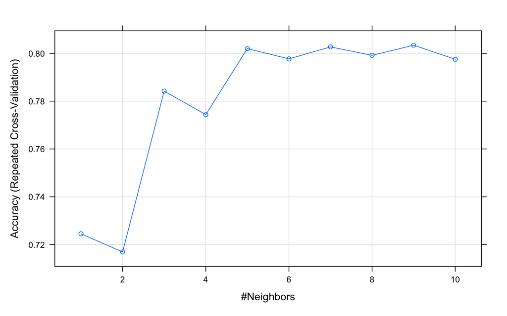

Accuracy is 77.1% while balanced accuracy is only 67.48%.

```r
knn_pred <- predict(knn.fit, newdata = knn_test)
# options('max.print' = 100)
# getOption("max.print")
confusionMatrix(knn_pred, knn_test$Loan_Status)
```

```
## Confusion Matrix and Statistics
##
##           Reference
## Prediction  0  1
##          0 16  6
##          1 22 78
##
##                Accuracy : 0.7705
##                  95% CI : (0.6857, 0.8418)
##     No Information Rate : 0.6885
##     P-Value [Acc > NIR] : 0.029156
##
##                   Kappa : 0.3952
##
##  Mcnemar's Test P-Value : 0.004586
##
##             Sensitivity : 0.4211
##             Specificity : 0.9286
##          Pos Pred Value : 0.7273
##          Neg Pred Value : 0.7800
##              Prevalence : 0.3115
##          Detection Rate : 0.1311
##    Detection Prevalence : 0.1803
##       Balanced Accuracy : 0.6748
##
##        'Positive' Class : 0
##
```